# Customer Churn Analysis

Zhe Wang

2025-06-19

## Setup: Load Required Packages

```r
library(tidyverse)
library(dplyr)
library(glmnet)
library(car)
library(randomForest)
library(naivebayes)
library(DT)
library(knitr)
library(gridExtra)
library(biotools)
library(tree)
library(caret)
library(pROC)
library(MASS)
library(e1071)
library(rpart)
library(rpart.plot)
```

## 1. Background and Business Context

### 1.1 The Challenge of Customer Churn in Telecommunications

In the highly competitive **telecommunications industry**, customer churn has become a major challenge.  
With many providers offering similar pricing and service bundles, customers frequently switch between companies.  
This volatility poses a serious risk to **long-term revenue stability**, making customer retention a strategic priority.

### 1.2 Cost of Acquisition vs. Retention

Acquiring a new customer can cost **5 to 25 times more** than retaining an existing one.  
Moreover, retained customers tend to generate more revenue over time through **upselling**, **cross-selling**, and **referrals**.  
Thus, an effective retention strategy not only reduces marketing expenses but also supports a **stable and loyal customer base**.

### 1.3 Importance of Churn Prediction

Predicting customer churn enables companies to shift from reactive to **proactive retention management**.  
By identifying high-risk customers early, companies can offer **personalized incentives**, resolve service issues, and apply **targeted engagement strategies**.  
This dual benefit helps reduce revenue loss while simultaneously strengthening customer satisfaction and brand loyalty.

## 2. Project Objective and Scope

### 2.1 Goal

Given the high cost of churn and the importance of customer retention, the main objective of this project is to **predict the likelihood of customer churn** to enable **proactive retention strategies**.  
By identifying customers at risk of leaving, the company can intervene early with incentives or service improvements to enhance loyalty.

### 2.2 Data Sources

This analysis is based on two datasets in **.rda format**:

- **Model_Building_Data**: Contains historical records of both current and churned customers. This dataset is used to **train and test machine learning models**.
- **Implementation_Data**: Contains current customers only. After model development, this dataset is used to **predict churn risk** and generate **business recommendations**.

### 2.3 Report Structure and Modeling Pipeline

The report is organized into the following sections:

1. **Data Preparation and Exploratory Analysis**: Clean and visualize the data to understand distributions and relationships with churn.
2. **Model Development**: Build predictive models using **Logistic Regression**, **Naive Bayes**, **LDA**, **QDA**, and **Decision Trees**.
3. **Model Evaluation and Comparison**: Assess model performance using **AUC**, **accuracy**, and interpretability.
4. **Business Recommendations**: Apply the best model to identify at-risk customers and propose a **cost-effective retention strategy**.

## 3. Data Preparation and Exploratory Data Analysis

### 3.1 Checking and handling missing values in “Model_Building_Data”

```r
# load the dataset "Model_Building_Data"
load("Model_Building_Data.rda")
```

#### 3.1.1 Checking and Understanding the dataset structure

Before proceeding with any analysis, it is important to first **understand the structure** of our dataset. This step ensures that all variables have been **correctly imported** and helps identify those that may require **transformation** before modeling.

The summary below provides a quick overview of the **variable types** and **example values** in the dataset named **Model_Building_Data_cleaned**, which contains historical customer information, including whether each customer has **churned** or **remained active**.

```r
# check and understand the dataset structure
glimpse(Model_Building_Data)
```

```
## Rows: 6,499
## Columns: 17
## $ Gender           <fct> Female, Male, Male, Male, Female, Female, Male, Femal…
## $ SeniorCitizen    <int> 0, 0, 0, 0, 0, 0, 0, 0, 0, 0, 0, 0, 0, 0, 0, 0, 0, 0,…
## $ Partner          <fct> Yes, No, No, No, No, No, No, No, Yes, No, Yes, No, Ye…
## $ Dependents       <fct> No, No, No, No, No, No, Yes, No, No, Yes, Yes, No, No…
## $ Tenure           <int> 1, 34, 2, 45, 2, 8, 22, 10, 28, 62, 13, 16, 58, 49, 2…
## $ PhoneService     <fct> No, Yes, Yes, No, Yes, Yes, Yes, No, Yes, Yes, Yes, Y…
## $ MultipleLines    <fct> No phone service, No, No, No phone service, No, Yes, …
## $ InternetService  <fct> DSL, DSL, DSL, DSL, Fiber optic, Fiber optic, Fiber o…
## $ OnlineSecurity   <fct> No, Yes, Yes, Yes, No, No, No, Yes, No, Yes, Yes, No …
## $ DeviceProtection <fct> No, Yes, No, Yes, No, Yes, No, No, Yes, No, No, No in…
## $ StreamingMovies  <fct> No, No, No, No, No, Yes, No, No, Yes, No, No, No inte…
## $ Contract         <fct> Month-to-month, One year, Month-to-month, One year, M…
## $ PaperlessBilling <fct> Yes, No, Yes, No, Yes, Yes, Yes, No, Yes, No, Yes, No…
## $ PaymentMethod    <fct> Electronic check, Mailed check, Mailed check, Bank tr…
## $ MonthlyCharges   <dbl> 29.85, 56.95, 53.85, 42.30, 70.70, 99.65, 89.10, 29.7…
## $ TotalCharges     <dbl> 29.85, 1889.50, 108.15, 1840.75, 151.65, 820.50, 1949…
## $ Status           <chr> "Current", "Current", "Left", "Current", "Left", "Lef…
```

Upon reviewing the data structure, we found that variables such as **SeniorCitizen** and **Status** were mistakenly recognized as **numeric** or **text** values rather than **categories**.

This misclassification could lead to inaccurate model behavior, as these fields represent **distinct groups**, not quantities.

To resolve this, we converted them into **categorical (factor) format**, allowing the models to correctly interpret and handle them as **group-based inputs**.

```r
# transform `SeniorCitizen` and `Status` into factor
Model_Building_Data_cleaned <- Model_Building_Data %>%
  mutate(SeniorCitizen = as.factor(SeniorCitizen)) %>%
  mutate(Status = as.factor(Status))
```

Now, let’s **re-examine the dataset structure** to verify that the **variable type conversions** have been correctly applied and that all features are now in a format suitable for further analysis.

```r
# check the dataset structrue again
glimpse(Model_Building_Data_cleaned)
```

```
## Rows: 6,499
## Columns: 17
## $ Gender           <fct> Female, Male, Male, Male, Female, Female, Male, Femal…
## $ SeniorCitizen    <fct> 0, 0, 0, 0, 0, 0, 0, 0, 0, 0, 0, 0, 0, 0, 0, 0, 0, 0,…
## $ Partner          <fct> Yes, No, No, No, No, No, No, No, Yes, No, Yes, No, Ye…
## $ Dependents       <fct> No, No, No, No, No, No, Yes, No, No, Yes, Yes, No, No…
## $ Tenure           <int> 1, 34, 2, 45, 2, 8, 22, 10, 28, 62, 13, 16, 58, 49, 2…
## $ PhoneService     <fct> No, Yes, Yes, No, Yes, Yes, Yes, No, Yes, Yes, Yes, Y…
## $ MultipleLines    <fct> No phone service, No, No, No phone service, No, Yes, …
## $ InternetService  <fct> DSL, DSL, DSL, DSL, Fiber optic, Fiber optic, Fiber o…
## $ OnlineSecurity   <fct> No, Yes, Yes, Yes, No, No, No, Yes, No, Yes, Yes, No …
## $ DeviceProtection <fct> No, Yes, No, Yes, No, Yes, No, No, Yes, No, No, No in…
## $ StreamingMovies  <fct> No, No, No, No, No, Yes, No, No, Yes, No, No, No inte…
## $ Contract         <fct> Month-to-month, One year, Month-to-month, One year, M…
## $ PaperlessBilling <fct> Yes, No, Yes, No, Yes, Yes, Yes, No, Yes, No, Yes, No…
## $ PaymentMethod    <fct> Electronic check, Mailed check, Mailed check, Bank tr…
## $ MonthlyCharges   <dbl> 29.85, 56.95, 53.85, 42.30, 70.70, 99.65, 89.10, 29.7…
## $ TotalCharges     <dbl> 29.85, 1889.50, 108.15, 1840.75, 151.65, 820.50, 1949…
## $ Status           <fct> Current, Current, Left, Current, Left, Left, Current,…
```

The dataset structure now appears to be **well-organized**, with **categorical variables correctly formatted** and ready for modeling and further analysis.

#### 3.1.2 Checking the missing values

Now that we have confirmed the structure of the dataset is appropriate, we proceed to **check for any missing values**. Identifying and handling missing data is a crucial step to ensure **model accuracy and reliability**.

```r
# check the summary of all columns
summary(Model_Building_Data_cleaned)
```

```
##     Gender     SeniorCitizen Partner    Dependents     Tenure      PhoneService
##  Female:3232   0:5452        No :3365   No :4551   Min.   : 0.00   No : 628
##  Male  :3267   1:1047        Yes:3134   Yes:1948   1st Qu.: 9.00   Yes:5871
##                                                    Median :29.00
##                                                    Mean   :32.26
##                                                    3rd Qu.:55.00
##                                                    Max.   :72.00
##
##           MultipleLines     InternetService             OnlineSecurity
##  No              :3140   DSL        :2221   No                 :3217
##  No phone service: 628   Fiber optic:2855   No internet service:1423
##  Yes             :2731   No         :1423   Yes                :1859
##
##
##
##
##             DeviceProtection            StreamingMovies           Contract
##  No                 :2849    No                 :2555   Month-to-month:3581
##  No internet service:1423    No internet service:1423   One year      :1352
##  Yes                :2227    Yes                :2521   Two year      :1566
##
##
##
##
##  PaperlessBilling                   PaymentMethod  MonthlyCharges
##  No :2658         Bank transfer (automatic):1425   Min.   : 18.25
##  Yes:3841         Credit card (automatic)  :1394   1st Qu.: 35.20
##                   Electronic check         :2171   Median : 70.35
##                   Mailed check             :1509   Mean   : 64.66
##                                                    3rd Qu.: 89.85
##                                                    Max.   :118.75
##
##   TotalCharges        Status
##  Min.   :  18.8   Current:4768
##  1st Qu.: 396.2   Left   :1731
##  Median :1389.7
##  Mean   :2273.5
##  3rd Qu.:3773.4
##  Max.   :8684.8
##  NA's   :11
```

Summary of Missing Values

Upon examining the dataset, we found that **the `TotalCharges` variable contains 11 missing values**.  
This is the **only variable** with missing data and represents a **very small portion of the total 6,499 observations**.

Given that `TotalCharges` is an important feature for our modeling process, we will address these missing values carefully in the next step to maintain data integrity.

#### 3.1.3 Understanding of “TotalCharges”

To better understand the nature of the missing values in **`TotalCharges`**, we first examine how this variable relates to other key billing attributes in the dataset.

```r
# exstract the first 10 Tenure, MonthlyCharges and TotalCharges
TE_MO_TC <- Model_Building_Data_cleaned %>%
  dplyr::select(Tenure, MonthlyCharges, TotalCharges) %>% mutate(Predicted_TotalCharges = Tenure * MonthlyCharges)
head(TE_MO_TC,10)
```

```
##    Tenure MonthlyCharges TotalCharges Predicted_TotalCharges
## 1       1          29.85        29.85                  29.85
## 2      34          56.95      1889.50                1936.30
## 3       2          53.85       108.15                 107.70
## 4      45          42.30      1840.75                1903.50
## 5       2          70.70       151.65                 141.40
## 6       8          99.65       820.50                 797.20
## 7      22          89.10      1949.40                1960.20
## 8      10          29.75       301.90                 297.50
## 9      28         104.80      3046.05                2934.40
## 10     62          56.15      3487.95                3481.30
```

Before deciding how to impute the missing values in `TotalCharges`, we first observe its relationship with other variables. We found that `TotalCharges` had a **strong relationship** with both `Tenure` and `MonthlyCharges`(almost TotalChagres equal Tenure mutipliy Tenure), which makes intuitive sense: **customers accumulate charges over time based on their monthly billing rate**.

#### 3.1.4 Check the Tenure and MonthlyCharges of those missing “TotalCharges”

To further investigate the **rows with missing `TotalCharges`**, we examine their corresponding **`Tenure`** and **`MonthlyCharges`** values to determine if there is a clear pattern or plausible explanation for the missingness.

```r
# view Tenure and Monthly Chambers in those rows with missing "TotalCharges"
Model_Building_Data_cleaned %>%
  filter(is.na(TotalCharges)) %>%
  dplyr::select(Tenure, MonthlyCharges)
```

```
##    Tenure MonthlyCharges
## 1       0          52.55
## 2       0          20.25
## 3       0          80.85
## 4       0          25.75
## 5       0          56.05
## 6       0          19.85
## 7       0          25.35
## 8       0          20.00
## 9       0          19.70
## 10      0          73.35
## 11      0          61.90
```

Handling Missing Values in `TotalCharges`

We found that all records with missing values in `TotalCharges` had a `Tenure` of 0, indicating that **these customers had just signed up and had not yet received their first bill**.

From a business perspective, it is reasonable to assume their total charges are **$0**, since no service usage has been billed.

To reflect this logic and maintain data quality, we replaced the missing values with **0**, instead of applying statistical imputation methods that may introduce unrealistic estimates.

```r
# if TotalCharges is missing and Tenure is 0, fill it with 0(safe way)
Model_Building_Data_cleaned$TotalCharges[
  is.na(Model_Building_Data_cleaned$TotalCharges) &
  Model_Building_Data_cleaned$Tenure == 0
] <- 0
```

After imputing the missing values in `TotalCharges`, we now **recheck the dataset structure** to ensure data consistency before proceeding with modeling tasks.

```r
# check the summary of all columns again
summary(Model_Building_Data_cleaned)
```

```
##     Gender     SeniorCitizen Partner    Dependents     Tenure      PhoneService
##  Female:3232   0:5452        No :3365   No :4551   Min.   : 0.00   No : 628
##  Male  :3267   1:1047        Yes:3134   Yes:1948   1st Qu.: 9.00   Yes:5871
##                                                    Median :29.00
##                                                    Mean   :32.26
##                                                    3rd Qu.:55.00
##                                                    Max.   :72.00
##           MultipleLines     InternetService             OnlineSecurity
##  No              :3140   DSL        :2221   No                 :3217
##  No phone service: 628   Fiber optic:2855   No internet service:1423
##  Yes             :2731   No         :1423   Yes                :1859
##
##
##
##             DeviceProtection            StreamingMovies           Contract
##  No                 :2849    No                 :2555   Month-to-month:3581
##  No internet service:1423    No internet service:1423   One year      :1352
##  Yes                :2227    Yes                :2521   Two year      :1566
##
##
##
##  PaperlessBilling                   PaymentMethod  MonthlyCharges
##  No :2658         Bank transfer (automatic):1425   Min.   : 18.25
##  Yes:3841         Credit card (automatic)  :1394   1st Qu.: 35.20
##                   Electronic check         :2171   Median : 70.35
##                   Mailed check             :1509   Mean   : 64.66
##                                                    3rd Qu.: 89.85
##                                                    Max.   :118.75
##   TotalCharges        Status
##  Min.   :   0.0   Current:4768
##  1st Qu.: 392.1   Left   :1731
##  Median :1387.5
##  Mean   :2269.6
##  3rd Qu.:3770.8
##  Max.   :8684.8
```

The updated structure confirms that the dataset is now **clean and complete**, with no remaining missing values in any key variable. This ensures that subsequent analyses will be based on a **reliable foundation**.

### 3.2 Explore the dataset and use data visualization to describe underlying trends.

Before diving into visualizations, we begin by reviewing the **data types and levels of all variables** in the dataset. This step is essential for ensuring that each variable is **properly formatted**—particularly categorical variables—so we can apply the appropriate statistical summaries and visualization techniques in the next sections.

```r
# check the structrue of each variable in dataset
str(Model_Building_Data_cleaned)
```

```
## 'data.frame':    6499 obs. of  17 variables:
##  $ Gender          : Factor w/ 2 levels "Female","Male": 1 2 2 2 1 1 2 1 1 2 ...
##  $ SeniorCitizen   : Factor w/ 2 levels "0","1": 1 1 1 1 1 1 1 1 1 1 ...
##  $ Partner         : Factor w/ 2 levels "No","Yes": 2 1 1 1 1 1 1 1 2 1 ...
##  $ Dependents      : Factor w/ 2 levels "No","Yes": 1 1 1 1 1 1 2 1 1 2 ...
##  $ Tenure          : int  1 34 2 45 2 8 22 10 28 62 ...
##  $ PhoneService    : Factor w/ 2 levels "No","Yes": 1 2 2 1 2 2 2 1 2 2 ...
##  $ MultipleLines   : Factor w/ 3 levels "No","No phone service",..: 2 1 1 2 1 3 3 2 3 1 ...
##  $ InternetService : Factor w/ 3 levels "DSL","Fiber optic",..: 1 1 1 1 2 2 2 1 2 1 ...
##  $ OnlineSecurity  : Factor w/ 3 levels "No","No internet service",..: 1 3 3 3 1 1 1 3 1 3 ...
##  $ DeviceProtection: Factor w/ 3 levels "No","No internet service",..: 1 3 1 3 1 3 1 1 3 1 ...
##  $ StreamingMovies : Factor w/ 3 levels "No","No internet service",..: 1 1 1 1 1 3 1 1 3 1 ...
##  $ Contract        : Factor w/ 3 levels "Month-to-month",..: 1 2 1 2 1 1 1 1 1 2 ...
##  $ PaperlessBilling: Factor w/ 2 levels "No","Yes": 2 1 2 1 2 2 2 1 2 1 ...
##  $ PaymentMethod   : Factor w/ 4 levels "Bank transfer (automatic)",..: 3 4 4 1 3 3 2 4 3 1 ...
##  $ MonthlyCharges  : num  29.9 57 53.9 42.3 70.7 ...
##  $ TotalCharges    : num  29.9 1889.5 108.2 1840.8 151.7 ...
##  $ Status          : Factor w/ 2 levels "Current","Left": 1 1 2 1 2 2 1 1 2 1 ...
```

#### 3.2.2 Use data visualization to describe underlying trends.

##### 3.2.2.1 User information categories(5): Gender, Senior Citizen, Partner, Dependents, Paperless Billing

To better understand the customer base, we begin our exploratory analysis with a visual inspection of several key **user demographic and billing attributes**. These include **Gender**, **Senior Citizen status**, **Partnership**, **Dependents**, and whether customers opted for **Paperless Billing**.

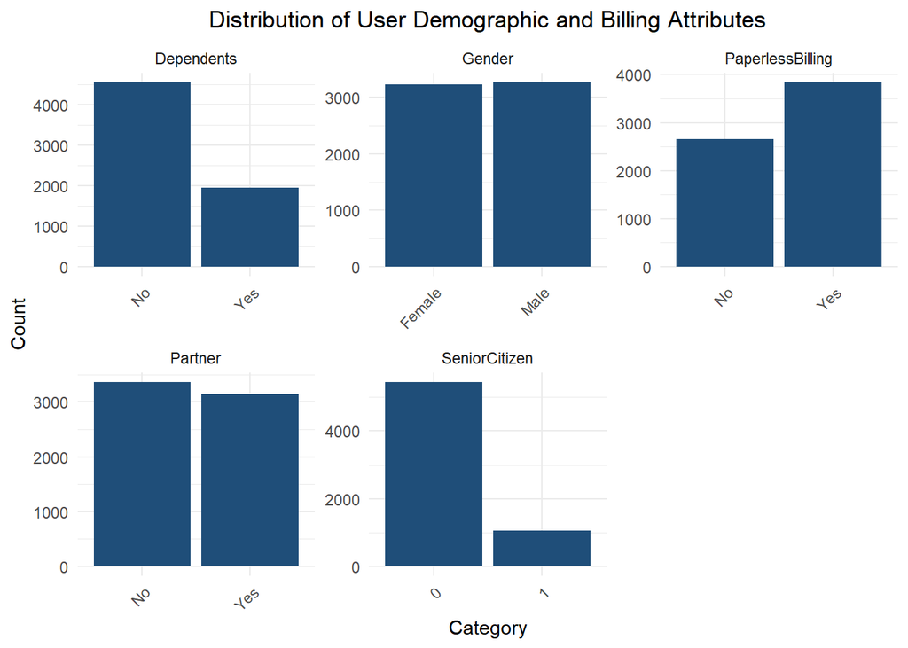

```r
# Subset relevant columns
user_info_data <- Model_Building_Data_cleaned %>%
  dplyr::select(Gender, SeniorCitizen, Partner, Dependents, PaperlessBilling)

# Reshape to long format for faceting
user_info_long <- user_info_data %>%
  pivot_longer(cols = everything(), names_to = "Variable", values_to = "Value")

# Create a faceted bar plot
ggplot(data = user_info_long, mapping = aes(x = Value)) +
  geom_bar(fill = "#1f4e79") +
  facet_wrap(~ Variable, scales = "free") +
  # Titles and labels
  labs(
    title = "Distribution of User Demographic and Billing Attributes",
    x = "Category",
    y = "Count",
    fill = "Category"
  ) +
  # Clean background
  theme_minimal() +
  # Centered title
  theme(
    plot.title = element_text(hjust = 0.5),
    axis.text.x = element_text(angle = 45, hjust = 1),
    legend.position = "none"
  )
```

User Demographic and Billing Variable Distributions

- The variable **Gender** shows a nearly even split between **male and female customers**, indicating no significant gender imbalance in the current customer base.
- **SeniorCitizen** is notably imbalanced: the vast majority of customers are **not senior citizens (0)**, with only about **16% classified as seniors (1)**.  
  This suggests that the company primarily serves a younger or middle-aged demographic.
- The **Partner** variable is relatively balanced, though slightly more customers **do not have a partner**, reflecting a diversity of household types.
- The **Dependents** variable is more skewed, with most customers reporting **no dependents**, potentially indicating a large portion of **independent or younger professionals**.
- **PaperlessBilling** is the dominant preference, showing that most users opt for **digital communication channels**, which presents an opportunity for **targeted retention messages** via email or app.
- Taken together, these demographic and preference variables suggest that the typical customer profile leans toward **non-senior, independent, and digitally engaged individuals** — a segment that may be more susceptible to churn and therefore key to focus on in retention planning.

##### 3.2.2.2 Service category (6): PhoneService, MultipleLines, InternetService, OnlineSecurity, DeviceProtection, StreamingMovies

We now turn our attention to **service-related attributes**, which capture customer subscription behavior across various offerings such as **InternetService**, **PhoneService**, **OnlineSecurity**, and more. Understanding these usage patterns provides important context for churn behavior.

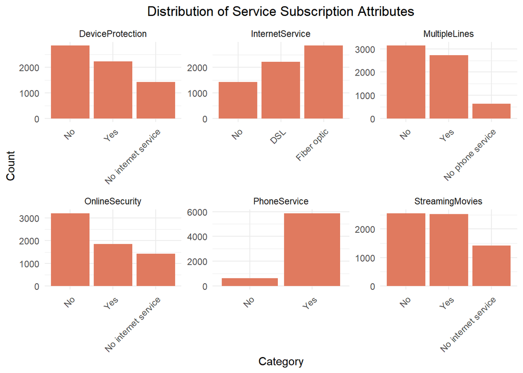

```r
# Select service-related variables
service_data <- Model_Building_Data_cleaned %>%
  dplyr::select(PhoneService, MultipleLines, InternetService,
         OnlineSecurity, DeviceProtection, StreamingMovies)

# Convert data to long format for faceted plotting
service_long <- service_data %>%
  pivot_longer(cols = everything(), names_to = "ServiceType", values_to = "Value")

# Plot distribution of service-related variables using faceted bar charts
ggplot(data = service_long, mapping = aes(x = Value)) +
  geom_bar(fill = "#e07a5f") +
  facet_wrap(~ ServiceType, scales = "free") +
  # add titles and axis labels
  labs(
    title = "Distribution of Service Subscription Attributes",
    x = "Category",
    y = "Count",
    fill = "Category"
  ) +
  # clean minimal background
  theme_minimal() +
  # center the title
  theme(
    plot.title = element_text(hjust = 0.5),
    axis.text.x = element_text(angle = 45, hjust = 1),
    legend.position = "none"
  )
```

Service Subscription Variable Distributions

- Most customers subscribe to **PhoneService**, confirming it as a core offering within the company’s service bundle. Very few customers opt out entirely.
- The **MultipleLines** variable contains three categories: “Yes”, “No”, and “No phone service”.  
  Among customers with phone service, there is a relatively even split between those with single and multiple lines.
- A majority of customers have **InternetService**, with **Fiber optic** and **DSL** being the dominant types.  
  A smaller portion report **no internet service**, likely reflecting low-usage or cost-sensitive segments.
- Optional services such as **OnlineSecurity**, **DeviceProtection**, and **StreamingMovies** exhibit high counts of “No” or “No internet service”.  
  This suggests that many customers have not opted into these add-ons.
- These trends indicate a potential **cross-selling opportunity**:  
  customers who already subscribe to internet services but lack additional features may be good candidates for **bundled offers** that include security or entertainment services.
- Service usage preferences show considerable variation, which may have a **significant impact on churn risk**.  
  These variables will be closely examined in the modeling sections to evaluate their predictive value.

##### 3.2.2.2 Contract and Payment Category(2): Contract, PaymentMethod

Next, we examine the **contract duration** and **payment method** preferences of customers. These variables are especially relevant for churn prediction, as they reflect commitment levels and billing habits.

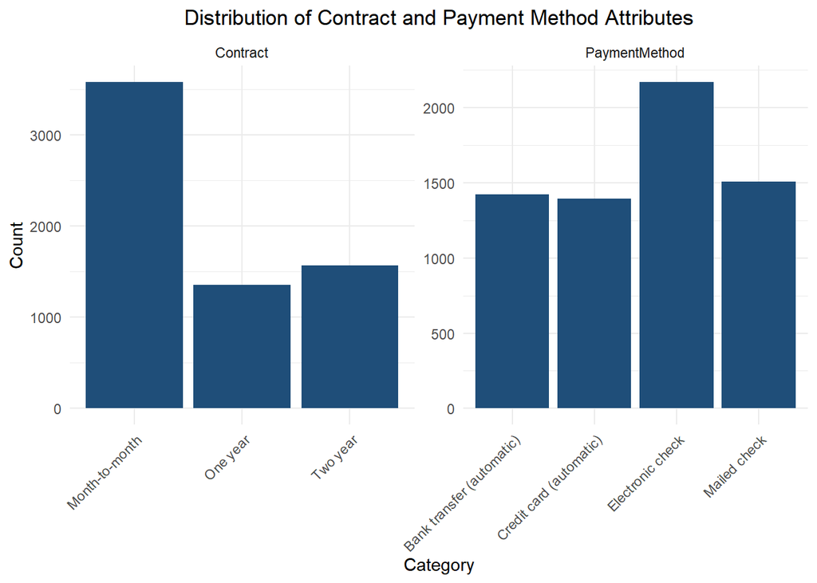

```r
# Select contract and payment method variables
contract_data <- Model_Building_Data_cleaned %>%
  dplyr::select(Contract, PaymentMethod)

# Reshape data for faceted plotting
contract_long <- contract_data %>%
  pivot_longer(cols = everything(), names_to = "ContractType", values_to = "Value")

# Plot bar charts for Contract and PaymentMethod
ggplot(data = contract_long, mapping = aes(x = Value)) +
  geom_bar(fill = "#1f4e79") +
  facet_wrap(~ ContractType, scales = "free") +
  labs(
    title = "Distribution of Contract and Payment Method Attributes",
    x = "Category",
    y = "Count",
    fill = "Category"
  ) +
  theme_minimal() +
  theme(
    plot.title = element_text(hjust = 0.5),
    axis.text.x = element_text(angle = 45, hjust = 1),
    legend.position = "none"
  )
```

Contract and Payment Method Distributions

- The majority of customers are on **Month-to-month contracts**, while **One-year** and **Two-year** plans are less common.  
  This suggests a strong customer preference for **flexibility over long-term commitment**, which may be associated with **higher churn risk**.
- Customers under longer-term contracts are generally more stable and less likely to leave.  
  As a result, **contract type emerges as a critical factor** in churn prediction and retention planning.
- Regarding payment methods, **Electronic check** is the most commonly used, followed by **Mailed check**, **Bank transfer (automatic)**, and **Credit card (automatic)**.
- Interestingly, a large portion of customers still rely on **manual payment methods**.  
  This may reflect **habitual behavior**, **limited digital engagement**, or **trust concerns** with automated systems.
- These patterns point to clear opportunities for improving retention, such as:
  - Promoting **longer-term contracts** through targeted discounts or loyalty incentives
  - Encouraging **automatic payments** to enhance billing continuity and reduce involuntary churn

##### 3.2.2.3 Numerical variables (Tenure, Monthly Charges, TotalCharges)

After reviewing the categorical variables, we now turn our attention to the **key numerical features** — `Tenure`, `MonthlyCharges`, and `TotalCharges`. Understanding the distribution of these continuous variables helps us detect customer segments, usage intensity, and potential outliers.

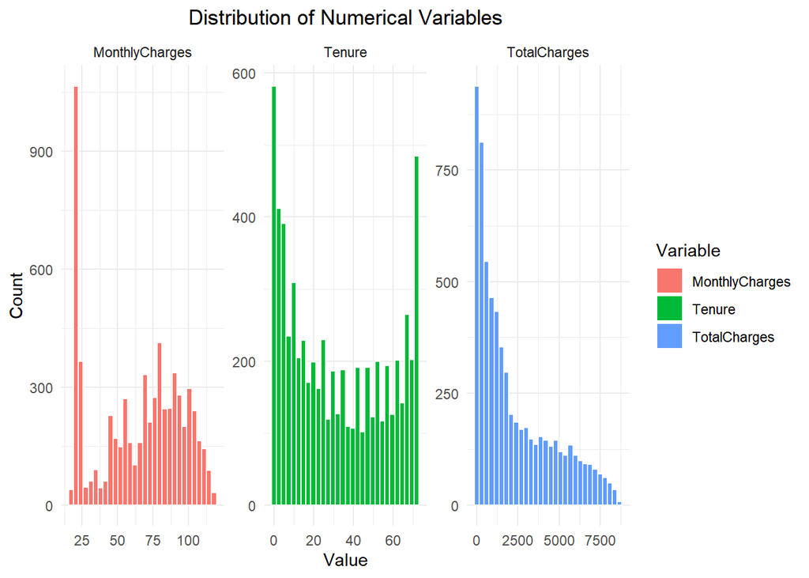

```r
# Select numeric variables
numeric_data <- Model_Building_Data_cleaned %>%
  dplyr::select(Tenure, MonthlyCharges, TotalCharges)

# Convert to long format
numeric_long <- numeric_data %>%
  pivot_longer(cols = everything(), names_to = "Variable", values_to = "Value")

# Plot histogram for each numeric variable
ggplot(data = numeric_long, mapping = aes(x = Value, fill = Variable)) +
  geom_histogram(bins = 30, color = "white") +
  facet_wrap(~ Variable, scales = "free") +
  # add titles and labels
  labs(
    title = "Distribution of Numerical Variables",
    x = "Value",
    y = "Count",
    fill = "Variable"
  ) +
  # clean visual style
  theme_minimal() +
  # center the title
  theme(
    plot.title = element_text(hjust = 0.5)
  )
```

**Numerical Variable Distributions**

### 3.3 Relationship between predictors and customer status

We selected variables where **the distribution of categories showed strong internal differences**, in order to examine **whether such within-variable variation is associated with changes in customer churn behavior.**

#### 3.3.1 Status Relationship - User Information Category Selection: Dependents, Senior Citizen, Paperless Billing

To better understand which user segments are more prone to churn, we now examine the relationship between **customer status** and selected **demographic and billing attributes**, including `Dependents`, `SeniorCitizen`, and `PaperlessBilling`.

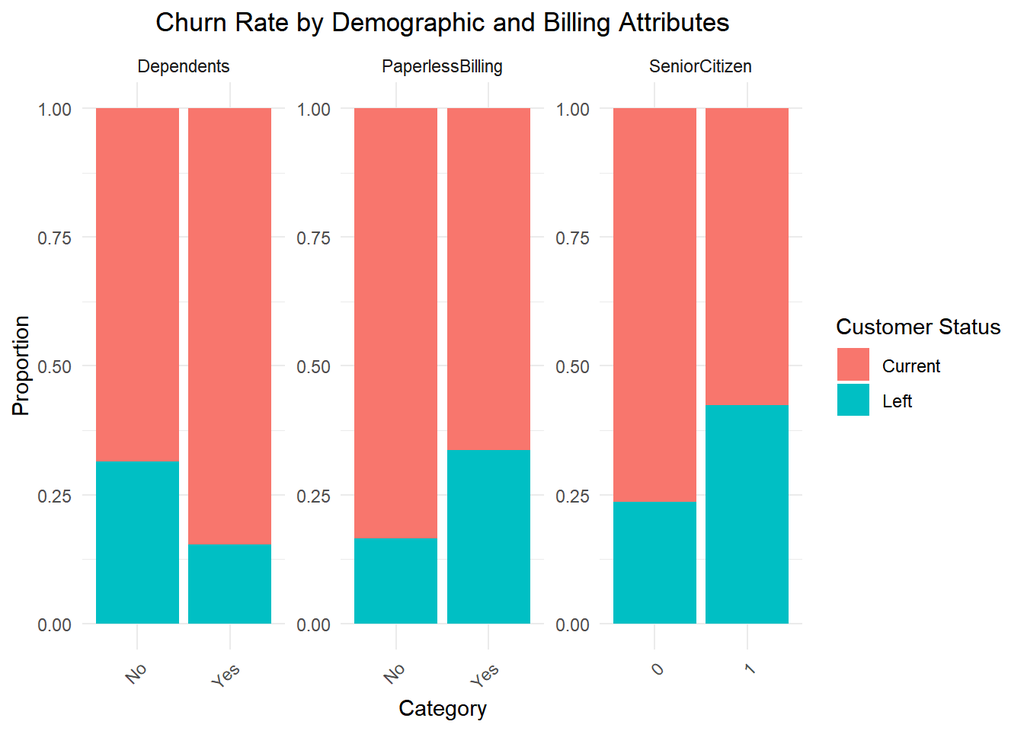

```r
# Select relevant user info variables with churn status
user_status_data <- Model_Building_Data_cleaned %>%
  dplyr::select(Status, Dependents, SeniorCitizen, PaperlessBilling)

# Convert to long format for faceted plotting
user_status_long <- user_status_data %>%
  pivot_longer(cols = -Status, names_to = "Variable", values_to = "Value")

# Plot stacked proportion bar chart (facet by variable)
ggplot(data = user_status_long, mapping = aes(x = Value, fill = Status)) +
  geom_bar(position = "fill") +
  facet_wrap(~ Variable, scales = "free") +
  # add titles and labels
  labs(
    title = "Churn Rate by Demographic and Billing Attributes",
    x = "Category",
    y = "Proportion",
    fill = "Customer Status"
  ) +
  # clean visual background
  theme_minimal() +
  # center the title
  theme(
    plot.title = element_text(hjust = 0.5),
    axis.text.x = element_text(angle = 45, hjust = 1)
  )
```

Churn Rates by Demographic Segments

The stacked proportion chart highlights **notable differences in churn behavior across customer groups**:

- Customers **without dependents** show a higher likelihood of churn.  
  This segment may be **more mobile, less rooted**, or **less reliant** on household service bundles.
- **Senior citizens** also exhibit elevated churn rates compared to younger customers.  
  Possible reasons include **price sensitivity**, **limited digital access**, or a **mismatch in service needs**.
- Customers who selected **paperless billing** are more prone to churn.  
  While this group is digitally engaged, they may also be **less loyal** or **more transactional** in nature.

These patterns suggest that **demographic and behavioral traits** can offer valuable signals for churn prediction.  
Retention strategies could be more effective if tailored toward **high-risk groups**, such as seniors and independent users.

#### 3.3.2 Status Relationship - Service Subscription Category Selection: InternetService, OnlineSecurity, PhoneService

Next, we shift our focus to service-related attributes to assess whether the **types of services subscribed** by customers are associated with different levels of churn risk. Specifically, we examine `InternetService`, `OnlineSecurity`, and `PhoneService`.

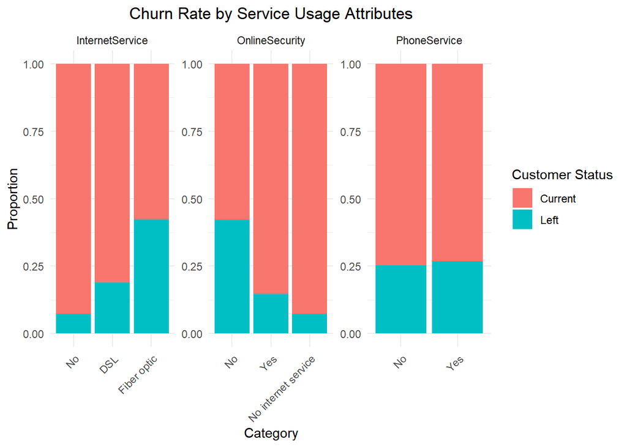

```r
# Select key service-related variables with churn status
service_status_data <- Model_Building_Data_cleaned %>%
  dplyr::select(Status, PhoneService, InternetService, OnlineSecurity)

# Convert to long format for faceted plotting
service_status_long <- service_status_data %>%
  pivot_longer(cols = -Status, names_to = "Variable", values_to = "Value")

# Plot stacked proportion bar chart (facet by service variable)
ggplot(data = service_status_long, mapping = aes(x = Value, fill = Status)) +
  geom_bar(position = "fill") +
  facet_wrap(~ Variable, scales = "free") +
  # add titles and labels
  labs(
    title = "Churn Rate by Service Usage Attributes",
    x = "Category",
    y = "Proportion",
    fill = "Customer Status"
  ) +
  # clean visual background
  theme_minimal() +
  # center the title
  theme(
    plot.title = element_text(hjust = 0.5),
    axis.text.x = element_text(angle = 45, hjust = 1)
  )
```

Churn Rates by Service Subscription Type